# Analytical Drivation of Kinematics and Workspace Evaluation of a 2-Link Planar Manipulator Using Python

# Kinematics Using DH Method

We assign the frames to our manipulator according to DH classic convention. DH method provides a convenient way to express the position and orienation of a rigid-body in matrix forms using the relevant link lengths, joint angles, twist angles and joint offsets.

### DH Table

The DH table for 2-Link Planar Mnipulator shown above can be formulated as,

\begin{array}{cccc} \hline \hline i & \alpha_{i} & a_{i} & d_i & \theta_i \\ \hline \hline 1 & 0 & l_1 & 0 & \theta_1 \\ 2 & 0 & l_2 & 0 & \theta_2 \\ %3 & -\frac{\pi}{2} & 0 & 0 & -\frac{\pi}{2} - \phi_1 \\ %4 & 0 & 0 & l_1 & 0 \\ \hline \end{array}

$i$: joint number, $\alpha_i$: twist angle, $a_i$: length of link $i$, $d_i$: joint offset and $\theta_i$: joint angle.

## Homogenous Transformation

The standard homogenous transformation matrix (transaformation from base to tip frame) is represnted as,

```python
rot = sp.Matrix([[sp.cos(theta), -sp.sin(theta)*sp.cos(alpha), sp.sin(theta)*sp.sin(alpha)],
             [sp.sin(theta), sp.cos(theta)*sp.cos(alpha), -sp.cos(theta)*sp.sin(alpha)],
             [0, sp.sin(alpha), sp.cos(alpha)]])

trans = sp.Matrix([a*sp.cos(theta),a*sp.sin(theta),d])

last_row = sp.Matrix([[0, 0, 0, 1]])

m = sp.Matrix.vstack(sp.Matrix.hstack(rot, trans), last_row)
m
```

$$\left[\begin{matrix}\operatorname{cos}\left(\theta\right) & - \operatorname{sin}\left(\theta\right) \operatorname{cos}\left(\alpha\right) & \operatorname{sin}\left(\alpha\right) \operatorname{sin}\left(\theta\right) & a \operatorname{cos}\left(\theta\right)\\\operatorname{sin}\left(\theta\right) & \operatorname{cos}\left(\alpha\right) \operatorname{cos}\left(\theta\right) & - \operatorname{sin}\left(\alpha\right) \operatorname{cos}\left(\theta\right) & a \operatorname{sin}\left(\theta\right)\\0 & \operatorname{sin}\left(\alpha\right) & \operatorname{cos}\left(\alpha\right) & d\\0 & 0 & 0 & 1\end{matrix}\right]$$

#### Transformation: frame '0' to '1'

```python
m01 = m.subs({alpha:0, a:l1, theta:theta1, d:0})
m01
```

$$\left[\begin{matrix}\operatorname{cos}\left(\theta_{1}\right) & - \operatorname{sin}\left(\theta_{1}\right) & 0 & l_{1} \operatorname{cos}\left(\theta_{1}\right)\\\operatorname{sin}\left(\theta_{1}\right) & \operatorname{cos}\left(\theta_{1}\right) & 0 & l_{1} \operatorname{sin}\left(\theta_{1}\right)\\0 & 0 & 1 & 0\\0 & 0 & 0 & 1\end{matrix}\right]$$

#### Transformation: frame '1' to '2'

```python
m12 = m.subs({alpha:0, a:l2, theta:theta2, d:0})
m12
```

$$\left[\begin{matrix}\operatorname{cos}\left(\theta_{2}\right) & - \operatorname{sin}\left(\theta_{2}\right) & 0 & l_{2} \operatorname{cos}\left(\theta_{2}\right)\\\operatorname{sin}\left(\theta_{2}\right) & \operatorname{cos}\left(\theta_{2}\right) & 0 & l_{2} \operatorname{sin}\left(\theta_{2}\right)\\0 & 0 & 1 & 0\\0 & 0 & 0 & 1\end{matrix}\right]$$

### Homogenous transformation: frame '0' to '2'

```python
m02 = (m01*m12)
m02
```

$$\left[\begin{matrix}- \operatorname{sin}\left(\theta_{1}\right) \operatorname{sin}\left(\theta_{2}\right) + \operatorname{cos}\left(\theta_{1}\right) \operatorname{cos}\left(\theta_{2}\right) & - \operatorname{sin}\left(\theta_{1}\right) \operatorname{cos}\left(\theta_{2}\right) - \operatorname{sin}\left(\theta_{2}\right) \operatorname{cos}\left(\theta_{1}\right) & 0 & l_{1} \operatorname{cos}\left(\theta_{1}\right) - l_{2} \operatorname{sin}\left(\theta_{1}\right) \operatorname{sin}\left(\theta_{2}\right) + l_{2} \operatorname{cos}\left(\theta_{1}\right) \operatorname{cos}\left(\theta_{2}\right)\\\operatorname{sin}\left(\theta_{1}\right) \operatorname{cos}\left(\theta_{2}\right) + \operatorname{sin}\left(\theta_{2}\right) \operatorname{cos}\left(\theta_{1}\right) & - \operatorname{sin}\left(\theta_{1}\right) \operatorname{sin}\left(\theta_{2}\right) + \operatorname{cos}\left(\theta_{1}\right) \operatorname{cos}\left(\theta_{2}\right) & 0 & l_{1} \operatorname{sin}\left(\theta_{1}\right) + l_{2} \operatorname{sin}\left(\theta_{1}\right) \operatorname{cos}\left(\theta_{2}\right) + l_{2} \operatorname{sin}\left(\theta_{2}\right) \operatorname{cos}\left(\theta_{1}\right)\\0 & 0 & 1 & 0\\0 & 0 & 0 & 1\end{matrix}\right]$$

Using Sympy's built-in simplification methods, we simplify the transformation matrix as

```python
mbee= sp.Matrix([[m02[0,0].simplify(), m02[0,1].simplify(), sp.trigsimp(m02[0,3].simplify())],
              [m02[1,0].simplify(), m02[1,1].simplify(), sp.trigsimp(m02[1,3].simplify())],
              [m02[2,0].simplify(), m02[2,1].simplify(), m02[2,2].simplify()]])

mbee
```

$$\left[\begin{matrix}\operatorname{cos}\left(\theta_{1} + \theta_{2}\right) & - \operatorname{sin}\left(\theta_{1} + \theta_{2}\right) & l_{1} \operatorname{cos}\left(\theta_{1}\right) + l_{2} \operatorname{cos}\left(\theta_{1} + \theta_{2}\right)\\\operatorname{sin}\left(\theta_{1} + \theta_{2}\right) & \operatorname{cos}\left(\theta_{1} + \theta_{2}\right) & l_{1} \operatorname{sin}\left(\theta_{1}\right) + l_{2} \operatorname{sin}\left(\theta_{1} + \theta_{2}\right)\\0 & 0 & 1\end{matrix}\right]$$

## Forward Kinematic Equations

The tip position can be expressed as,

#### Position in x-direction

```python
px = mbee[0,2]
px
```

$$l_{1} \operatorname{cos}\left(\theta_{1}\right) + l_{2} \operatorname{cos}\left(\theta_{1} + \theta_{2}\right)$$

#### Position in y-direction

```python
py = mbee[1,2]
py
```

$$l_{1} \operatorname{sin}\left(\theta_{1}\right) + l_{2} \operatorname{sin}\left(\theta_{1} + \theta_{2}\right)$$

# Numerical evlaution of tip position

```python
fx = sp.lambdify((l1, l2, theta1, theta2), px, 'numpy')
fy = sp.lambdify((l1, l2, theta1, theta2), py, 'numpy')
```

To plot tip position in X and Y, we import Matplotlib and Numpy. For inline plot display, we use Ipython magic.

```python
import matplotlib.pyplot as plt
%matplotlib inline
import numpy as np
d2r = np.deg2rad # for degree to radian conversion
r2d = np.rad2deg # for radian to degree conversion
```

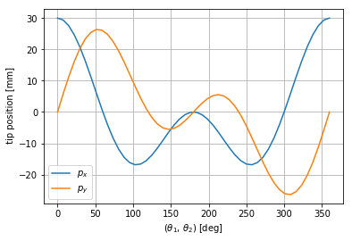

```python
theta1s = np.linspace(d2r(0), d2r(360)) # desired range of motion for joint 1
theta2s = np.linspace(d2r(0), d2r(360)) # desired range of motion for joint 2

zx = np.array(fx(15.0, 15.0, theta1s, theta2s))
zy = np.array(fy(15.0, 15.0, theta1s, theta2s))

fig, ax1 = plt.subplots()
ax1.plot(r2d(theta1s), zx, label = r'$p_x$')
ax1.plot(r2d(theta1s), zy, label = r'$p_y$')
ax1.set_xlabel(r'($\theta_1$, $\theta_2$) [deg]')
ax1.set_ylabel(r' tip position [mm]')
plt.legend()
plt.grid()
```

# Manipulator Workspace

The next step is to visualize the workspce of our manipulator. For this purpose, we will import Plotly and make sure that it displays inline plot in our notebook environment.

```python
from plotly.offline import download_plotlyjs, init_notebook_mode, plot, iplot
init_notebook_mode(connected=True) # for offline mode in Jupyter Notebook use

import plotly.offline as py
import plotly.graph_objs as go
from numpy import * # Not recommended, but we use to avoid rewriting the forward kinematic equations with prefix 'np'
```

```python
theta11 = np.linspace(d2r(0),d2r(90))
theta22 = np.linspace(d2r(0), d2r(360))
theta1, theta2 = np.meshgrid(theta11, theta22)
l_range = [5] # we can use more than one value here

px1 = {}
py1 = {}
pz1 = {}
for i in l_range:
    l1 = i
    l2 = i - 4

    pxa = l1*cos(theta1) + l2*cos(theta1 + theta2)
    pya = l1*sin(theta1) + l2*sin(theta1 + theta2)

    px1['x{0}'.format(i)] = pxa
    py1['x{0}'.format(i)] = pya
```

```python
pxx = px1['x5']
pyy = py1['x5']
pzz = pyy*0 #dummy zero points for z-axis, as it doesn't exist
```

```python
trace1 = go.Surface(z=pzz, x=pyy, y=pxx,
                    colorscale='Reds',
                    showscale=False,
                    opacity=0.7,
                   )
data = [trace1]
```

```python
layout = go.Layout(
    scene = dict(
                    xaxis = dict(
                        title='Trans (mm)',
                    ),
                    yaxis = dict(
                        title='Yaw (mm)',
                    ),
                    zaxis = dict(
                        title='Pitch (mm)',
                    ),),
)
```

```python
fig = go.Figure(data=data, layout=layout)
py.iplot(fig)
```

[interactive chart not shown]

This concludes our post. To summarize, we symbolically derived the kinematics of the 2-link manipulator and plotted visualized it's workspace.

In the next post, we will learn how to achieve the same results without using DH parameters. We will use Sympy to derive the kinematics and will show that the obtained results by both method are mathematically identical.